# FussWithJacobOutput

Canaan

2023-01-26

# now do model evals

```r
eval_metrics_ur <- read_csv("ModelEvalLogs.csv") %>%
  mutate(vowel_skeleton = str_replace_all(proposed_form, "[$\' ()ptkq]","")) %>%
  mutate(clean_vowels = case_when(
    str_detect(vowel_skeleton, "iI") ~ 0,
    str_detect(vowel_skeleton, "iE") ~ 0,
    str_detect(vowel_skeleton, "eI") ~ 0,
    str_detect(vowel_skeleton, "eE") ~ 0,
    str_detect(vowel_skeleton, "Ii") ~ 0,
    str_detect(vowel_skeleton, "Ie") ~ 0,
    str_detect(vowel_skeleton, "Ei") ~ 0,
    str_detect(vowel_skeleton, "Ee") ~ 0,
    T ~ 1
  )) %>%
  mutate(IsNotSpuriousTI = if_else(IsTI == TRUE & clean_vowels == 1, 1,0))#
```

```
##
## mutate: new variable 'vowel_skeleton' (character) with 452 unique values and 0% NA
##
## mutate: new variable 'clean_vowels' (double) with 2 unique values and 0% NA
##
## mutate: new variable 'IsNotSpuriousTI' (double) with 2 unique values and 0% NA
```

```r
eval_metrics <- eval_metrics_ur %>%
  filter(IsNotSpuriousTI == 1)
```

```
## filter: removed 1,397 rows (97%), 43 rows remaining
```

```
## filter: no rows removed
```

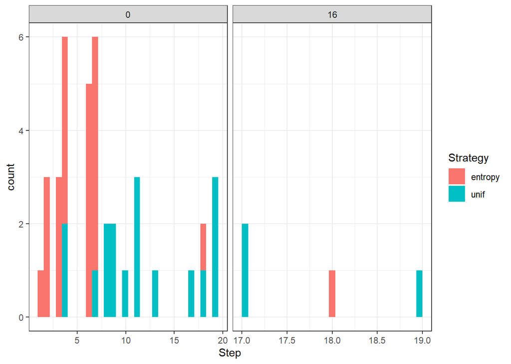

```r
eval_metrics %>%
  filter(Strategy != "train") %>%
  ggplot(aes(x=Step, fill = Strategy))+
  #geom_density(aes(alpha=0.4))+
  geom_histogram()+
  theme_bw()+
  facet_wrap(~N_Init, scales = "free_x")
```

```r
# so it looks like the entropy measures is asking about discerning forms first.

# what is the distribution of average firsts like across runs?

s <- eval_metrics %>%
  filter(Strategy != "train") %>%
  group_by(Run,Strategy,N_Init) %>%
  summarise(t = min(Step-N_Init)) %>%
  ungroup() %>%
  group_by(Strategy,N_Init) %>%
  summarise(mean_queries_before_critical = mean(t))
```

```
## filter: no rows removed
## group_by: 3 grouping variables (Run, Strategy, N_Init)
## summarise: now 31 rows and 4 columns, 2 group variables remaining (Run, Strategy)
## ungroup: no grouping variables
## group_by: 2 grouping variables (Strategy, N_Init)
## summarise: now 4 rows and 3 columns, one group variable remaining (Strategy)
```

match points in feature evolution with cases in classifier

```r
t <- read_csv("FeatureProbs.csv", col_names = T )
points_to_get_features_for <- eval_metrics %>%
  filter(Strategy != "train") %>%
  group_by(Run,Strategy,N_Init) %>%
  summarise(first_occurrence = min(Step)) #%>%
```

```
## filter: no rows removed
## group_by: 3 grouping variables (Run, Strategy, N_Init)
## summarise: now 31 rows and 4 columns, 2 group variables remaining (Run, Strategy)
```

```r
d <- c()

for (i in 1:nrow(points_to_get_features_for)){

  current_row <- points_to_get_features_for[i,]

  current_row$Relation <- "Current"
  doctored_before <- current_row
    doctored_before$first_occurrence <- current_row$first_occurrence-1
doctored_before$Relation <- "Before"
  doctored_after <- current_row

  doctored_after$first_occurrence <- current_row$first_occurrence+1
  doctored_after$Relation <- "After"

    d[[length(d)+1]] <- doctored_before
  d[[length(d)+1]] <- current_row

  d[[length(d)+1]] <- doctored_after
}

rows_to_get_full_data_for <- d %>% bind_rows() %>%
  rename(Step = first_occurrence)
```

```
## rename: renamed one variable (Step)
```

```r
rows_with_accuracy_data <- rows_to_get_full_data_for %>%
  left_join(eval_metrics_ur) %>%
  left_join(t) %>%
  mutate(Relation = fct_relevel(Relation, c("Before","Current","After")))
```

```
## left_join: added 12 columns (ent, good, bad, diff, acc, …)
## > rows only in x 2
## > rows only in y (1,349)
## > matched rows 91
## > =======
## > rows total 93
## left_join: added 4 columns (feature, cost, Candidate, Judgment)
## > rows only in x 2
## > rows only in y (690,688)
## > matched rows 46,592 (includes duplicates)
## > =========
## > rows total 46,594
## mutate (grouped): converted 'Relation' from character to factor (0 new NA)
```

```r
# now we have the metrics for the step before the first time seeing the most informative token by each strategy, run, and N_Init
```

now plot some of this

```
## select: dropped 15 variables (ent, good, bad, acc, rej, …)
```

```
## distinct (grouped): removed 46,501 rows (>99%), 93 rows remaining
```

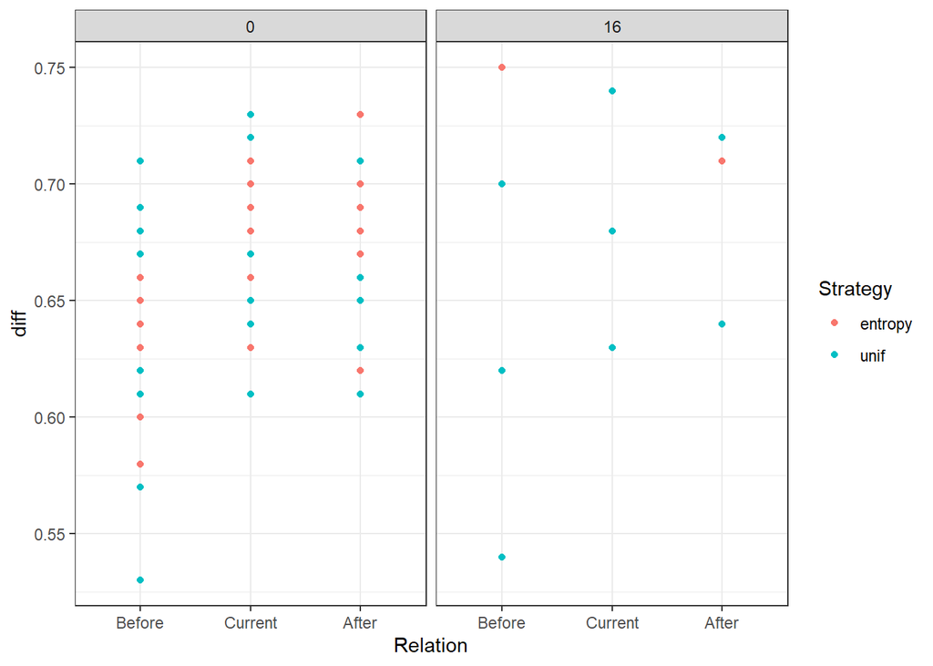

```r
rows_with_accuracy_data %>%
  select(Run,Strategy,N_Init,Step,Relation,diff) %>%
  distinct() %>%
  ggplot(aes(x = Relation, y = diff, color = Strategy, group = Strategy))+
  geom_point()+
  #geom_smooth()+
  theme_bw()+
  facet_wrap(~N_Init)
```

```
## select: dropped 15 variables (Step, ent, good, bad, diff, …)
```

```
## group_by: 4 grouping variables (Strategy, N_Init, Relation, feature)
```

```
## summarise: now 6,146 rows and 5 columns, 3 group variables remaining (Strategy, N_Init, Relation)
```

[figure not shown]

```r
rows_with_accuracy_data %>%
  select(Run,Strategy,N_Init,Relation,feature,cost) %>%
  group_by(Strategy,N_Init,Relation,feature) %>%
  summarise(mean_cost = mean(cost)) %>%
  #arrange(mean_cost) %>%
  ggplot(aes(x = Relation, y = feature, fill = mean_cost))+
  #geom_jitter()+
  geom_tile()+
  theme_bw()+
  facet_wrap(~N_Init*Strategy)
```

```
## filter (grouped): removed 46,412 rows (>99%), 182 rows remaining
```

```
## select: dropped 15 variables (Step, ent, good, bad, diff, …)
```

```
## group_by: 4 grouping variables (Strategy, N_Init, Relation, feature)
```

```
## summarise: now 24 rows and 5 columns, 3 group variables remaining (Strategy, N_Init, Relation)
```

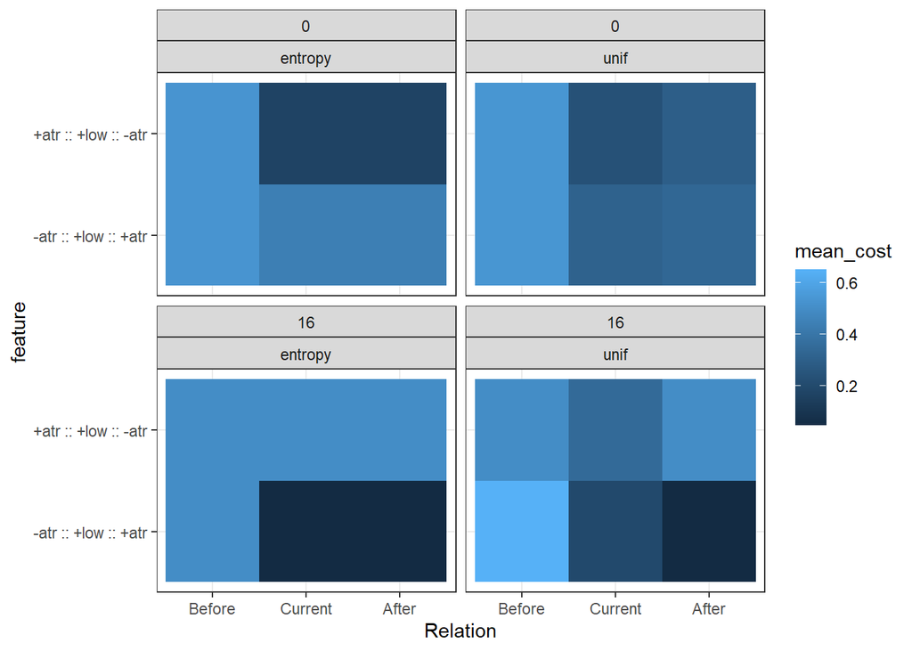

```r
rows_with_accuracy_data %>%
  filter(feature %in% c("+atr :: +low :: -atr", "-atr :: +low :: +atr")) %>%
  select(Run,Strategy,N_Init,Relation,feature,cost)%>%
  group_by(Strategy,N_Init,Relation,feature) %>%
  summarise(mean_cost = mean(cost)) %>%
  #arrange(mean_cost) %>%
  ggplot(aes(x = Relation, y = feature, fill = mean_cost))+
  #geom_jitter()+
  geom_tile()+
  theme_bw()+
  facet_wrap(~N_Init*Strategy)
```

```r
u <- read_csv("HoldoutEvals.csv") %>%
  rename(N_Init = N_INIT)
```

```
##
## rename: renamed one variable (N_Init)
```

```r
narrow_test <- u %>%
  filter(TestType == "NarrowTest") %>%
  group_by(Strategy,Run,Step,N_Init) %>%
  summarise(mean_cost = mean(Cost))
```

```
## filter: removed 25,316,640 rows (>99%), 11,520 rows remaining
## group_by: 4 grouping variables (Strategy, Run, Step, N_Init)
## summarise: now 1,440 rows and 5 columns, 3 group variables remaining (Strategy, Run, Step)
```

```r
broad_test <- u %>%
  filter(TestType == "BroadTest") %>%
  group_by(Strategy,Run,Step,N_Init) %>%
  summarise(mean_cost = mean(Cost))
```

```
## filter: removed 11,520 rows (<1%), 25,316,640 rows remaining
## group_by: 4 grouping variables (Strategy, Run, Step, N_Init)
## summarise: now 1,440 rows and 5 columns, 3 group variables remaining (Strategy, Run, Step)
```

```r
rows_with_narrow_holdout_data <- rows_to_get_full_data_for %>%
  left_join(narrow_test) %>%
  mutate(Relation = fct_relevel(Relation, c("Before","Current","After")))
```

```
## left_join: added one column (mean_cost)
## > rows only in x 2
## > rows only in y (1,349)
## > matched rows 91
## > =======
## > rows total 93
## mutate (grouped): converted 'Relation' from character to factor (0 new NA)
```

```r
rows_with_broad_holdout_data <- rows_to_get_full_data_for %>%
  left_join(broad_test) %>%
  mutate(Relation = fct_relevel(Relation, c("Before","Current","After")))
```

```
## left_join: added one column (mean_cost)
## > rows only in x 2
## > rows only in y (1,349)
## > matched rows 91
## > =======
## > rows total 93
## mutate (grouped): converted 'Relation' from character to factor (0 new NA)
```

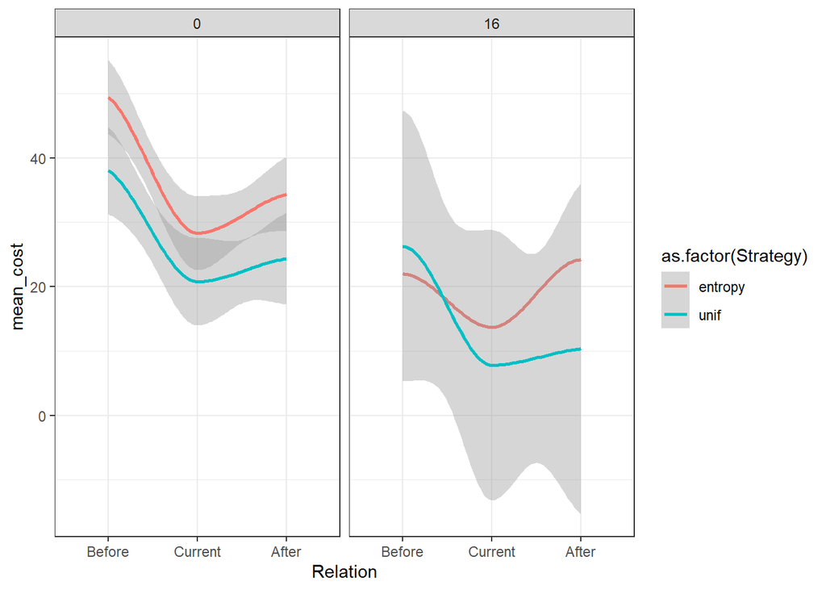

```r
rows_with_narrow_holdout_data %>%
  ggplot(aes(x=Relation, y = mean_cost, group = Strategy, color = as.factor(Strategy)))+
  geom_smooth()+
  theme_bw()+
  facet_wrap(~N_Init)
```

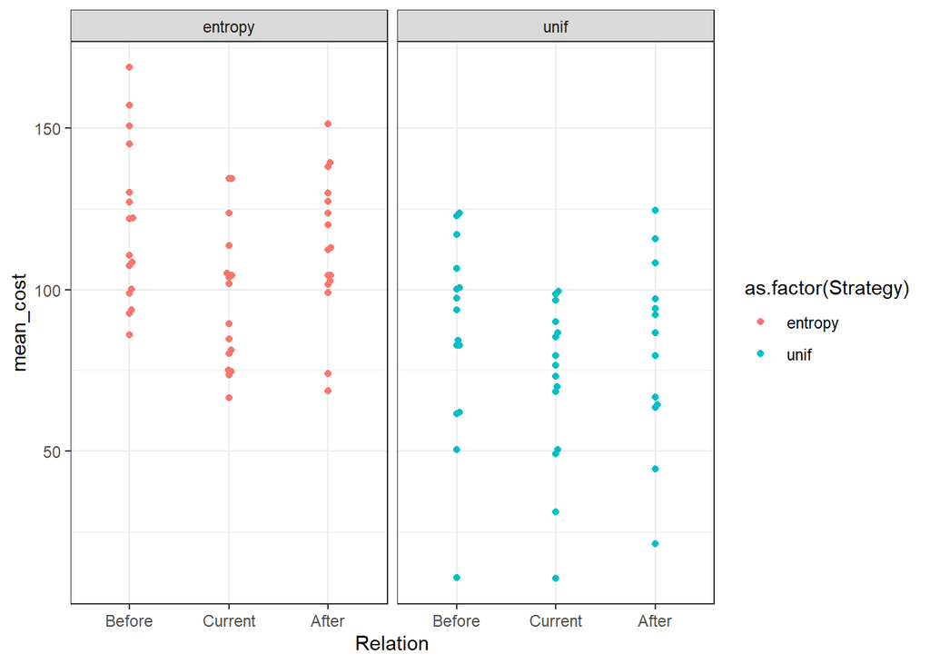

```r
rows_with_broad_holdout_data %>%
  ggplot(aes(x=Relation, y = mean_cost, group = Strategy, color = as.factor(Strategy)))+
  geom_beeswarm()+
  theme_bw()+
  facet_wrap(~Strategy)
```

```r
eval_metrics_ur %>%
  filter(Strategy != "train") %>%
  select(Step,Run,proposed_form,N_Init,Strategy) %>%
  group_by(Strategy,N_Init) %>%
  summarise(diversity_of_proposed_forms = n_distinct(proposed_form))
```

```
## filter: removed 480 rows (33%), 960 rows remaining
## select: dropped 11 variables (ent, good, bad, diff, acc, …)
## group_by: 2 grouping variables (Strategy, N_Init)
## summarise: now 4 rows and 3 columns, one group variable remaining (Strategy)
```

```
## # A tibble: 4 × 3
## # Groups:   Strategy [2]
##   Strategy N_Init diversity_of_proposed_forms
##   <chr>     <dbl>                       <int>
## 1 entropy       0                         398
## 2 entropy      16                          79
## 3 unif          0                         378
## 4 unif         16                          80
```

okay, so, broadly true if we get negative judgments, but it doesn’t change under non-informativeness.

so the learner *should*, as soon as we have evidence for the licensed feature combo, push to zero, but all the other cases should be bumped up a bit, right?

it seems like there’s the issue of rejections not being bumped up enough (or at all)

# analysis of synthetic characteristics of data

```r
corpus_stats <- read_csv("analysis_of_characteristics_of_synthetic_data.csv") %>%
  mutate(NSylls = str_count(WordContainingIt, " ")+1)
```

```
##
## mutate: new variable 'NSylls' (double) with 10 unique values and <1% NA
```

how rare are telling sequences?

```r
s <- corpus_stats %>%
  select(-WordContainingIt,-TellingSubsequence) %>%
  group_by(NSylls,ProperJudgementForWord) %>%
  summarise(n = n()) %>%
  pivot_wider(values_from = n, names_from = ProperJudgementForWord) %>%
  mutate(percent_telling_tokens = bad/(okay+bad))
```

```
## select: dropped 2 variables (TellingSubsequence, WordContainingIt)
```

```
## group_by: 2 grouping variables (NSylls, ProperJudgementForWord)
```

```
## summarise: now 17 rows and 3 columns, one group variable remaining (NSylls)
```

```
## pivot_wider: reorganized (ProperJudgementForWord, n) into (okay, bad) [was 17x3, now 10x3]
```

```
## mutate (grouped): new variable 'percent_telling_tokens' (double) with 8 unique values and 30% NA
```

so according to this, telling examples that /a/ is opaque are very rare. but that’s in the true corpus, not hard to find in the proposals, right? that’s the plot above.

I guess the question is how often until we discover that; right? its easy to learn that there is atr harmony, and that a doesn’t participate, but less obvious that a is transparent?

# see how the model feels about the space of possible words over time - extensional evaluatino

```r
words <- read_csv("WordsAndScores_atr.csv") %>%
  filter(!is.na(Word)) %>%
  mutate(TypeOfEvidence = case_when(
    OkUnderTransparentHarmony == TRUE & OkUnderOpaqueHarmony == TRUE ~ "OkUnderBoth",
    OkUnderTransparentHarmony == FALSE & OkUnderOpaqueHarmony == TRUE ~ "OnlyOkUnderOpaqueHarmony",
    OkUnderTransparentHarmony == FALSE & OkUnderOpaqueHarmony == FALSE ~ "BadUnderBoth",
    OkUnderTransparentHarmony == TRUE & OkUnderOpaqueHarmony == FALSE ~ "ERROR"
  )) %>%
  select(Word,JudgeScore,TypeOfEvidence)

scores <- read_csv("HumanEvalLogs.csv") %>%
  rename(Word = Item) %>%
  select(-Source)

full <- left_join(words,scores, by = "Word")

full %>%
  filter(N_INIT == 0,
         Step <=10) %>%
  ggplot(aes(x=Step, y = Cost, group = TypeOfEvidence, color = TypeOfEvidence))+
  geom_smooth()+
  facet_wrap(~Strategy, scales = "free_y")+
  theme_bw()
ggsave("EvalJudgments.jpeg",height=10,width=10)

#
# ah <- a %>%
#   filter(Source == "AH_2003",
#   #       Strategy == "train"
#   ) %>%
#   ggplot(aes(x=Step,y=r, group=Strategy, color = Strategy))+
#   geom_hline(yintercept = as.numeric(oracles[1,2])*-1, linetype = "dashed", color = "red")+
#   geom_smooth()+
#   ylim(-1,1)+
#   theme_bw()+
#   theme(legend.position = "none")+
#   facet_wrap(~Source)
# ah
# jlhw <- a %>%
#   filter(Source == "JLHW_Canaan",
#   #       Strategy == "train"
#   ) %>%
#   ggplot(aes(x=Step,y=r, group=Strategy, color = Strategy))+
#   geom_hline(yintercept = as.numeric(oracles[2,2])*-1, linetype = "dashed", color = "red")+
#   geom_smooth()+
#   ylim(-1,1)+
#   theme_bw()+
#   theme(legend.position = "none")+
#   facet_wrap(~Source)
# jlhw
# scholes <- a %>%
#   filter(Source == "Scholes",
#   #       Strategy == "train"
#   ) %>%
#   ggplot(aes(x=Step,y=r, group=Strategy, color = Strategy))+
#   geom_hline(yintercept = as.numeric(oracles[3,2])*-1, linetype = "dashed", color = "red")+
#   geom_smooth()+
#   ylim(-1,1)+
#   theme_bw()+
#   theme(legend.position = "right")+
#   facet_wrap(~Source)
# scholes
#
# p <- plot_grid(ah,jlhw,scholes, nrow = 1, rel_widths = c(1,1,1.5))
# p
#
# ggsave("EvalJudgments_WithInformant.jpeg",height=7,width=10)
```

[output not shown]

# feature query analysis

```r
features_queried_about_ur <- read_file("feature_query_log.csv")

features_queried_about <- features_queried_about_ur %>%
  str_replace_all("\', \'"," ") %>%
  str_split("\\r\\n") %>%
  unlist() %>%
  as_tibble() %>%
  separate(value, ",", into = c("1",'2','3','4','5','6')) %>%
  row_to_names(row_number = 1)
a <- features_queried_about %>%
  mutate(t_group = paste0(N_Init,Strategy,Run)) %>%
  select(Feature,Step,t_group)
```

```
## mutate: new variable 't_group' (character) with 121 unique values and 0% NA
```

```
## select: dropped 4 variables (Candidate, N_Init, Strategy, Run)
```

```r
num_distinct_groups <- a %>%
  select(t_group) %>%
  distinct()
```

```
## select: dropped 2 variables (Feature, Step)
```

```
## distinct: removed 67,392 rows (>99%), 121 rows remaining
```

```r
list_of_feats_at_this_step <- list()
list_of_feats_to_date <- list()


for (row in 1:nrow(num_distinct_groups)){
  #print(row)
  #print(num_distinct_groups[row,])
  current_group_name <- as.character(num_distinct_groups[row,])
  #print(current_group_name)

  just_that_group <- a %>%
    filter(t_group == current_group_name) # current_group_name
  steps <- just_that_group %>%
    select(Step) %>%
    distinct()
  previous_step_features <- tibble()
  for (step in 1:nrow(steps)){
    #print(step)
    current_step_name <- as.character(steps[step,])
    just_that_step <- just_that_group %>%
      filter(Step == current_step_name)
    this_step_features <- just_that_step %>%
      select(Feature) %>%
      distinct()
    num_features_at_this_step <- nrow(this_step_features)
    total_features_to_date_in_this_group <- previous_step_features %>%
      rbind(this_step_features) %>%
      distinct()
    previous_step_features <- total_features_to_date_in_this_group
    num_features_to_date_in_this_group <- total_features_to_date_in_this_group %>%
      nrow()
    #print(paste0("this is step ",current_step_name," in group ",current_group_name,". There are  this many unique features ",num_features_at_this_step," and this many total features to date in this group ",num_features_to_date_in_this_group))

    list_of_feats_at_this_step[[length(list_of_feats_at_this_step)+1]] <- num_features_at_this_step
    list_of_feats_to_date[[length(list_of_feats_to_date)+1]] <- num_features_to_date_in_this_group


  }
}
```

[output not shown]

[output not shown]

[output not shown]

[output not shown]

[output not shown]

[output not shown]

[output not shown]

[output not shown]

[output not shown]

[output not shown]

[output not shown]

[output not shown]

[output not shown]

[output not shown]

[output not shown]

[output not shown]

[output not shown]

[output not shown]

[output not shown]

[output not shown]

```
## select: dropped 2 variables (Step, t_group)
```

```
## distinct: no rows removed
```

```
## distinct: removed 37 rows (16%), 196 rows remaining
```

```
## filter: removed 1,245 rows (96%), 51 rows remaining
```

```
## select: dropped 2 variables (Step, t_group)
```

```
## distinct: no rows removed
```

```
## distinct: removed 32 rows (13%), 215 rows remaining
```

```
## filter: removed 1,254 rows (97%), 42 rows remaining
```

```
## select: dropped 2 variables (Step, t_group)
```

```
## distinct: no rows removed
```

```
## distinct: removed 23 rows (9%), 234 rows remaining
```

```
## filter: removed 1,224 rows (94%), 72 rows remaining
```

```
## select: dropped 2 variables (Step, t_group)
```

```
## distinct: removed 6 rows (8%), 66 rows remaining
```

```
## distinct: removed 58 rows (19%), 242 rows remaining
```

```
## filter: removed 1,224 rows (94%), 72 rows remaining
```

```
## select: dropped 2 variables (Step, t_group)
```

```
## distinct: removed 4 rows (6%), 68 rows remaining
```

```
## distinct: removed 65 rows (21%), 245 rows remaining
```

```
## filter: removed 1,224 rows (94%), 72 rows remaining
```

```
## select: dropped 2 variables (Step, t_group)
```

```
## distinct: removed one row (1%), 71 rows remaining
```

```
## distinct: removed 70 rows (22%), 246 rows remaining
```

```
## filter: removed 1,224 rows (94%), 72 rows remaining
```

```
## select: dropped 2 variables (Step, t_group)
```

```
## distinct: removed 4 rows (6%), 68 rows remaining
```

```
## distinct: removed 67 rows (21%), 247 rows remaining
```

```
## filter: removed 1,260 rows (97%), 36 rows remaining
```

```
## select: dropped 2 variables (Step, t_group)
```

```
## distinct: no rows removed
```

```
## distinct: removed 21 rows (7%), 262 rows remaining
```

```
## filter: removed 1,236 rows (95%), 60 rows remaining
```

```
## select: dropped 2 variables (Step, t_group)
```

```
## distinct: no rows removed
```

```
## distinct: removed 56 rows (17%), 266 rows remaining
```

```
## filter: removed 1,224 rows (94%), 72 rows remaining
```

```
## select: dropped 2 variables (Step, t_group)
```

```
## distinct: removed 4 rows (6%), 68 rows remaining
```

```
## distinct: removed 68 rows (20%), 266 rows remaining
```

```
## filter: removed 1,224 rows (94%), 72 rows remaining
```

```
## select: dropped 2 variables (Step, t_group)
```

```
## distinct: removed 2 rows (3%), 70 rows remaining
```

```
## distinct: removed 70 rows (21%), 266 rows remaining
```

```
## filter: removed 1,224 rows (94%), 72 rows remaining
```

```
## select: dropped 2 variables (Step, t_group)
```

```
## distinct: removed one row (1%), 71 rows remaining
```

```
## distinct: removed 71 rows (21%), 266 rows remaining
```

```
## filter: removed 1,224 rows (94%), 72 rows remaining
```

```
## select: dropped 2 variables (Step, t_group)
```

```
## distinct: removed 2 rows (3%), 70 rows remaining
```

```
## distinct: removed 70 rows (21%), 266 rows remaining
```

```
## filter: removed 1,224 rows (94%), 72 rows remaining
```

```
## select: dropped 2 variables (Step, t_group)
```

```
## distinct: removed one row (1%), 71 rows remaining
```

```
## distinct: removed 71 rows (21%), 266 rows remaining
```

```
## filter: removed 1,224 rows (94%), 72 rows remaining
```

```
## select: dropped 2 variables (Step, t_group)
```

```
## distinct: removed 2 rows (3%), 70 rows remaining
```

```
## distinct: removed 70 rows (21%), 266 rows remaining
```

```
## filter: removed 1,224 rows (94%), 72 rows remaining
```

```
## select: dropped 2 variables (Step, t_group)
```

```
## distinct: removed 2 rows (3%), 70 rows remaining
```

```
## distinct: removed 70 rows (21%), 266 rows remaining
```

[output not shown]

```
## select: dropped 2 variables (Feature, t_group)
```

```
## distinct: removed 584 rows (97%), 20 rows remaining
```

```
## filter: removed 586 rows (97%), 18 rows remaining
```

```
## select: dropped 2 variables (Step, t_group)
```

```
## distinct: no rows removed
## distinct: no rows removed
```

```
## filter: removed 574 rows (95%), 30 rows remaining
```

```
## select: dropped 2 variables (Step, t_group)
```

```
## distinct: no rows removed
```

```
## distinct: removed 5 rows (10%), 43 rows remaining
```

```
## filter: removed 553 rows (92%), 51 rows remaining
```

```
## select: dropped 2 variables (Step, t_group)
```

```
## distinct: no rows removed
```

```
## distinct: removed 22 rows (23%), 72 rows remaining
```

```
## filter: removed 559 rows (93%), 45 rows remaining
```

```
## select: dropped 2 variables (Step, t_group)
```

```
## distinct: no rows removed
```

```
## distinct: removed 20 rows (17%), 97 rows remaining
```

```
## filter: removed 586 rows (97%), 18 rows remaining
```

```
## select: dropped 2 variables (Step, t_group)
```

```
## distinct: no rows removed
```

```
## distinct: removed 8 rows (7%), 107 rows remaining
```

```
## filter: removed 571 rows (95%), 33 rows remaining
```

```
## select: dropped 2 variables (Step, t_group)
```

```
## distinct: no rows removed
```

```
## distinct: removed 10 rows (7%), 130 rows remaining
```

```
## filter: removed 586 rows (97%), 18 rows remaining
```

```
## select: dropped 2 variables (Step, t_group)
```

```
## distinct: no rows removed
```

```
## distinct: removed 17 rows (11%), 131 rows remaining
```

```
## filter: removed 571 rows (95%), 33 rows remaining
```

```
## select: dropped 2 variables (Step, t_group)
```

```
## distinct: no rows removed
```

```
## distinct: removed 17 rows (10%), 147 rows remaining
```

```
## filter: removed 562 rows (93%), 42 rows remaining
```

```
## select: dropped 2 variables (Step, t_group)
```

```
## distinct: no rows removed
```

```
## distinct: removed 33 rows (17%), 156 rows remaining
```

```
## filter: removed 592 rows (98%), 12 rows remaining
```

```
## select: dropped 2 variables (Step, t_group)
```

```
## distinct: no rows removed
```

```
## distinct: removed 10 rows (6%), 158 rows remaining
```

```
## filter: removed 553 rows (92%), 51 rows remaining
```

```
## select: dropped 2 variables (Step, t_group)
```

```
## distinct: no rows removed
```

```
## distinct: removed 42 rows (20%), 167 rows remaining
```

```
## filter: removed 582 rows (96%), 22 rows remaining
```

```
## select: dropped 2 variables (Step, t_group)
```

```
## distinct: no rows removed
```

```
## distinct: removed 16 rows (8%), 173 rows remaining
```

```
## filter: removed 592 rows (98%), 12 rows remaining
```

```
## select: dropped 2 variables (Step, t_group)
```

```
## distinct: no rows removed
```

```
## distinct: removed 12 rows (6%), 173 rows remaining
```

```
## filter: removed 532 rows (88%), 72 rows remaining
```

```
## select: dropped 2 variables (Step, t_group)
```

```
## distinct: removed 4 rows (6%), 68 rows remaining
```

```
## distinct: removed 41 rows (17%), 200 rows remaining
```

```
## filter: removed 592 rows (98%), 12 rows remaining
```

```
## select: dropped 2 variables (Step, t_group)
```

```
## distinct: no rows removed
```

```
## distinct: removed 12 rows (6%), 200 rows remaining
```

```
## filter: removed 586 rows (97%), 18 rows remaining
```

```
## select: dropped 2 variables (Step, t_group)
```

```
## distinct: no rows removed
```

```
## distinct: removed 17 rows (8%), 201 rows remaining
```

```
## filter: removed 586 rows (97%), 18 rows remaining
```

```
## select: dropped 2 variables (Step, t_group)
```

```
## distinct: no rows removed
```

```
## distinct: removed 18 rows (8%), 201 rows remaining
```

```
## filter: removed 559 rows (93%), 45 rows remaining
```

```
## select: dropped 2 variables (Step, t_group)
```

```
## distinct: no rows removed
```

```
## distinct: removed 43 rows (17%), 203 rows remaining
```

```
## filter: removed 568 rows (94%), 36 rows remaining
```

```
## select: dropped 2 variables (Step, t_group)
```

```
## distinct: no rows removed
```

```
## distinct: removed 31 rows (13%), 208 rows remaining
```

```
## filter: removed 586 rows (97%), 18 rows remaining
```

```
## select: dropped 2 variables (Step, t_group)
```

```
## distinct: no rows removed
```

```
## distinct: removed 18 rows (8%), 208 rows remaining
```

[output not shown]

```
## select: dropped 2 variables (Feature, t_group)
```

```
## distinct: removed 733 rows (97%), 20 rows remaining
```

```
## filter: removed 693 rows (92%), 60 rows remaining
```

```
## select: dropped 2 variables (Step, t_group)
```

```
## distinct: no rows removed
## distinct: no rows removed
```

```
## filter: removed 729 rows (97%), 24 rows remaining
```

```
## select: dropped 2 variables (Step, t_group)
```

```
## distinct: no rows removed
```

```
## distinct: removed 2 rows (2%), 82 rows remaining
```

```
## filter: removed 729 rows (97%), 24 rows remaining
```

```
## select: dropped 2 variables (Step, t_group)
```

```
## distinct: no rows removed
```

```
## distinct: removed 18 rows (17%), 88 rows remaining
```

```
## filter: removed 696 rows (92%), 57 rows remaining
```

```
## select: dropped 2 variables (Step, t_group)
```

```
## distinct: no rows removed
```

```
## distinct: removed 18 rows (12%), 127 rows remaining
```

```
## filter: removed 731 rows (97%), 22 rows remaining
```

```
## select: dropped 2 variables (Step, t_group)
```

```
## distinct: no rows removed
```

```
## distinct: removed 20 rows (13%), 129 rows remaining
```

```
## filter: removed 723 rows (96%), 30 rows remaining
```

```
## select: dropped 2 variables (Step, t_group)
```

```
## distinct: no rows removed
```

```
## distinct: removed 2 rows (1%), 157 rows remaining
```

```
## filter: removed 693 rows (92%), 60 rows remaining
```

```
## select: dropped 2 variables (Step, t_group)
```

```
## distinct: no rows removed
```

```
## distinct: removed 42 rows (19%), 175 rows remaining
```

```
## filter: removed 735 rows (98%), 18 rows remaining
```

```
## select: dropped 2 variables (Step, t_group)
```

```
## distinct: no rows removed
```

```
## distinct: removed 12 rows (6%), 181 rows remaining
```

```
## filter: removed 720 rows (96%), 33 rows remaining
```

```
## select: dropped 2 variables (Step, t_group)
```

```
## distinct: no rows removed
```

```
## distinct: removed 31 rows (14%), 183 rows remaining
```

```
## filter: removed 681 rows (90%), 72 rows remaining
```

```
## select: dropped 2 variables (Step, t_group)
```

```
## distinct: removed 12 rows (17%), 60 rows remaining
```

```
## distinct: removed 50 rows (21%), 193 rows remaining
```

```
## filter: removed 711 rows (94%), 42 rows remaining
```

```
## select: dropped 2 variables (Step, t_group)
```

```
## distinct: no rows removed
```

```
## distinct: removed 33 rows (14%), 202 rows remaining
```

```
## filter: removed 723 rows (96%), 30 rows remaining
```

```
## select: dropped 2 variables (Step, t_group)
```

```
## distinct: no rows removed
```

```
## distinct: removed 30 rows (13%), 202 rows remaining
```

```
## filter: removed 731 rows (97%), 22 rows remaining
```

```
## select: dropped 2 variables (Step, t_group)
```

```
## distinct: no rows removed
```

```
## distinct: removed 20 rows (9%), 204 rows remaining
```

```
## filter: removed 681 rows (90%), 72 rows remaining
```

```
## select: dropped 2 variables (Step, t_group)
```

```
## distinct: removed 27 rows (38%), 45 rows remaining
```

```
## distinct: removed 40 rows (16%), 209 rows remaining
```

```
## filter: removed 720 rows (96%), 33 rows remaining
```

```
## select: dropped 2 variables (Step, t_group)
```

```
## distinct: no rows removed
```

```
## distinct: removed 33 rows (14%), 209 rows remaining
```

```
## filter: removed 737 rows (98%), 16 rows remaining
```

```
## select: dropped 2 variables (Step, t_group)
```

```
## distinct: no rows removed
```

```
## distinct: removed 13 rows (6%), 212 rows remaining
```

```
## filter: removed 720 rows (96%), 33 rows remaining
```

```
## select: dropped 2 variables (Step, t_group)
```

```
## distinct: no rows removed
```

```
## distinct: removed 30 rows (12%), 215 rows remaining
```

```
## filter: removed 731 rows (97%), 22 rows remaining
```

```
## select: dropped 2 variables (Step, t_group)
```

```
## distinct: no rows removed
```

```
## distinct: removed 22 rows (9%), 215 rows remaining
```

```
## filter: removed 708 rows (94%), 45 rows remaining
```

```
## select: dropped 2 variables (Step, t_group)
```

```
## distinct: no rows removed
```

```
## distinct: removed 37 rows (14%), 223 rows remaining
```

```
## filter: removed 715 rows (95%), 38 rows remaining
```

```
## select: dropped 2 variables (Step, t_group)
```

```
## distinct: removed 12 rows (32%), 26 rows remaining
```

```
## distinct: removed 26 rows (10%), 223 rows remaining
```

[output not shown]

```
## select: dropped 2 variables (Feature, t_group)
```

```
## distinct: removed 1,291 rows (98%), 20 rows remaining
```

```
## filter: removed 1,239 rows (95%), 72 rows remaining
```

```
## select: dropped 2 variables (Step, t_group)
```

```
## distinct: removed 2 rows (3%), 70 rows remaining
```

```
## distinct: no rows removed
```

```
## filter: removed 1,239 rows (95%), 72 rows remaining
```

```
## select: dropped 2 variables (Step, t_group)
```

```
## distinct: removed 3 rows (4%), 69 rows remaining
```

```
## distinct: removed 26 rows (19%), 113 rows remaining
```

```
## filter: removed 1,260 rows (96%), 51 rows remaining
```

```
## select: dropped 2 variables (Step, t_group)
```

```
## distinct: no rows removed
```

```
## distinct: removed 13 rows (8%), 151 rows remaining
```

```
## filter: removed 1,251 rows (95%), 60 rows remaining
```

```
## select: dropped 2 variables (Step, t_group)
```

```
## distinct: no rows removed
```

```
## distinct: removed 37 rows (18%), 174 rows remaining
```

```
## filter: removed 1,260 rows (96%), 51 rows remaining
```

```
## select: dropped 2 variables (Step, t_group)
```

```
## distinct: no rows removed
```

```
## distinct: removed 24 rows (11%), 201 rows remaining
```

```
## filter: removed 1,251 rows (95%), 60 rows remaining
```

```
## select: dropped 2 variables (Step, t_group)
```

```
## distinct: no rows removed
```

```
## distinct: removed 45 rows (17%), 216 rows remaining
```

```
## filter: removed 1,251 rows (95%), 60 rows remaining
```

```
## select: dropped 2 variables (Step, t_group)
```

```
## distinct: removed 4 rows (7%), 56 rows remaining
```

```
## distinct: removed 37 rows (14%), 235 rows remaining
```

```
## filter: removed 1,239 rows (95%), 72 rows remaining
```

```
## select: dropped 2 variables (Step, t_group)
```

```
## distinct: removed 6 rows (8%), 66 rows remaining
```

```
## distinct: removed 63 rows (21%), 238 rows remaining
```

```
## filter: removed 1,269 rows (97%), 42 rows remaining
```

```
## select: dropped 2 variables (Step, t_group)
```

```
## distinct: removed one row (2%), 41 rows remaining
```

```
## distinct: removed 24 rows (9%), 255 rows remaining
```

```
## filter: removed 1,239 rows (95%), 72 rows remaining
```

```
## select: dropped 2 variables (Step, t_group)
```

```
## distinct: removed 2 rows (3%), 70 rows remaining
```

```
## distinct: removed 70 rows (22%), 255 rows remaining
```

```
## filter: removed 1,239 rows (95%), 72 rows remaining
```

```
## select: dropped 2 variables (Step, t_group)
```

```
## distinct: removed one row (1%), 71 rows remaining
```

```
## distinct: removed 71 rows (22%), 255 rows remaining
```

```
## filter: removed 1,260 rows (96%), 51 rows remaining
```

```
## select: dropped 2 variables (Step, t_group)
```

```
## distinct: no rows removed
```

```
## distinct: removed 43 rows (14%), 263 rows remaining
```

```
## filter: removed 1,239 rows (95%), 72 rows remaining
```

```
## select: dropped 2 variables (Step, t_group)
```

```
## distinct: removed one row (1%), 71 rows remaining
```

```
## distinct: removed 71 rows (21%), 263 rows remaining
```

```
## filter: removed 1,239 rows (95%), 72 rows remaining
```

```
## select: dropped 2 variables (Step, t_group)
```

```
## distinct: removed 3 rows (4%), 69 rows remaining
```

```
## distinct: removed 68 rows (20%), 264 rows remaining
```

```
## filter: removed 1,239 rows (95%), 72 rows remaining
```

```
## select: dropped 2 variables (Step, t_group)
```

```
## distinct: removed 2 rows (3%), 70 rows remaining
```

```
## distinct: removed 70 rows (21%), 264 rows remaining
```

```
## filter: removed 1,239 rows (95%), 72 rows remaining
```

```
## select: dropped 2 variables (Step, t_group)
```

```
## distinct: removed 2 rows (3%), 70 rows remaining
```

```
## distinct: removed 70 rows (21%), 264 rows remaining
```

```
## filter: removed 1,239 rows (95%), 72 rows remaining
```

```
## select: dropped 2 variables (Step, t_group)
```

```
## distinct: removed 6 rows (8%), 66 rows remaining
```

```
## distinct: removed 65 rows (20%), 265 rows remaining
```

```
## filter: removed 1,239 rows (95%), 72 rows remaining
```

```
## select: dropped 2 variables (Step, t_group)
```

```
## distinct: removed 2 rows (3%), 70 rows remaining
```

```
## distinct: removed 70 rows (21%), 265 rows remaining
```

```
## filter: removed 1,239 rows (95%), 72 rows remaining
```

```
## select: dropped 2 variables (Step, t_group)
```

```
## distinct: removed 4 rows (6%), 68 rows remaining
```

```
## distinct: removed 68 rows (20%), 265 rows remaining
```

```
## filter: removed 1,239 rows (95%), 72 rows remaining
```

```
## select: dropped 2 variables (Step, t_group)
```

```
## distinct: removed 3 rows (4%), 69 rows remaining
```

```
## distinct: removed 69 rows (21%), 265 rows remaining
```

[output not shown]

```
## select: dropped 2 variables (Feature, t_group)
```

```
## distinct: removed 718 rows (97%), 20 rows remaining
```

```
## filter: removed 693 rows (94%), 45 rows remaining
```

```
## select: dropped 2 variables (Step, t_group)
```

```
## distinct: no rows removed
## distinct: no rows removed
```

```
## filter: removed 666 rows (90%), 72 rows remaining
```

```
## select: dropped 2 variables (Step, t_group)
```

```
## distinct: removed 12 rows (17%), 60 rows remaining
```

```
## distinct: removed 22 rows (21%), 83 rows remaining
```

```
## filter: removed 666 rows (90%), 72 rows remaining
```

```
## select: dropped 2 variables (Step, t_group)
```

```
## distinct: removed 2 rows (3%), 70 rows remaining
```

```
## distinct: removed 38 rows (25%), 115 rows remaining
```

```
## filter: removed 720 rows (98%), 18 rows remaining
```

```
## select: dropped 2 variables (Step, t_group)
```

```
## distinct: no rows removed
```

```
## distinct: removed 16 rows (12%), 117 rows remaining
```

```
## filter: removed 720 rows (98%), 18 rows remaining
```

```
## select: dropped 2 variables (Step, t_group)
```

```
## distinct: no rows removed
```

```
## distinct: removed 11 rows (8%), 124 rows remaining
```

```
## filter: removed 720 rows (98%), 18 rows remaining
```

```
## select: dropped 2 variables (Step, t_group)
```

```
## distinct: no rows removed
```

```
## distinct: removed 16 rows (11%), 126 rows remaining
```

```
## filter: removed 705 rows (96%), 33 rows remaining
```

```
## select: dropped 2 variables (Step, t_group)
```

```
## distinct: no rows removed
```

```
## distinct: removed 18 rows (11%), 141 rows remaining
```

```
## filter: removed 687 rows (93%), 51 rows remaining
```

```
## select: dropped 2 variables (Step, t_group)
```

```
## distinct: no rows removed
```

```
## distinct: removed 30 rows (16%), 162 rows remaining
```

```
## filter: removed 726 rows (98%), 12 rows remaining
```

```
## select: dropped 2 variables (Step, t_group)
```

```
## distinct: no rows removed
```

```
## distinct: removed 8 rows (5%), 166 rows remaining
```

```
## filter: removed 720 rows (98%), 18 rows remaining
```

```
## select: dropped 2 variables (Step, t_group)
```

```
## distinct: no rows removed
```

```
## distinct: removed 18 rows (10%), 166 rows remaining
```

```
## filter: removed 687 rows (93%), 51 rows remaining
```

```
## select: dropped 2 variables (Step, t_group)
```

```
## distinct: no rows removed
```

```
## distinct: removed 46 rows (21%), 171 rows remaining
```

```
## filter: removed 726 rows (98%), 12 rows remaining
```

```
## select: dropped 2 variables (Step, t_group)
```

```
## distinct: no rows removed
```

```
## distinct: removed 9 rows (5%), 174 rows remaining
```

```
## filter: removed 666 rows (90%), 72 rows remaining
```

```
## select: dropped 2 variables (Step, t_group)
```

```
## distinct: removed 6 rows (8%), 66 rows remaining
```

```
## distinct: removed 59 rows (25%), 181 rows remaining
```

```
## filter: removed 720 rows (98%), 18 rows remaining
```

```
## select: dropped 2 variables (Step, t_group)
```

```
## distinct: no rows removed
```

```
## distinct: removed 16 rows (8%), 183 rows remaining
```

```
## filter: removed 693 rows (94%), 45 rows remaining
```

```
## select: dropped 2 variables (Step, t_group)
```

```
## distinct: no rows removed
```

```
## distinct: removed 33 rows (14%), 195 rows remaining
```

```
## filter: removed 687 rows (93%), 51 rows remaining
```

```
## select: dropped 2 variables (Step, t_group)
```

```
## distinct: no rows removed
```

```
## distinct: removed 41 rows (17%), 205 rows remaining
```

```
## filter: removed 720 rows (98%), 18 rows remaining
```

```
## select: dropped 2 variables (Step, t_group)
```

```
## distinct: no rows removed
```

```
## distinct: removed 18 rows (8%), 205 rows remaining
```

```
## filter: removed 720 rows (98%), 18 rows remaining
```

```
## select: dropped 2 variables (Step, t_group)
```

```
## distinct: no rows removed
```

```
## distinct: removed 18 rows (8%), 205 rows remaining
```

```
## filter: removed 693 rows (94%), 45 rows remaining
```

```
## select: dropped 2 variables (Step, t_group)
```

```
## distinct: no rows removed
```

```
## distinct: removed 45 rows (18%), 205 rows remaining
```

```
## filter: removed 687 rows (93%), 51 rows remaining
```

```
## select: dropped 2 variables (Step, t_group)
```

```
## distinct: no rows removed
```

```
## distinct: removed 50 rows (20%), 206 rows remaining
```

[output not shown]

```
## select: dropped 2 variables (Feature, t_group)
```

```
## distinct: removed 733 rows (97%), 20 rows remaining
```

```
## filter: removed 693 rows (92%), 60 rows remaining
```

```
## select: dropped 2 variables (Step, t_group)
```

```
## distinct: no rows removed
## distinct: no rows removed
```

```
## filter: removed 729 rows (97%), 24 rows remaining
```

```
## select: dropped 2 variables (Step, t_group)
```

```
## distinct: no rows removed
```

```
## distinct: removed 2 rows (2%), 82 rows remaining
```

```
## filter: removed 729 rows (97%), 24 rows remaining
```

```
## select: dropped 2 variables (Step, t_group)
```

```
## distinct: no rows removed
```

```
## distinct: removed 18 rows (17%), 88 rows remaining
```

```
## filter: removed 696 rows (92%), 57 rows remaining
```

```
## select: dropped 2 variables (Step, t_group)
```

```
## distinct: no rows removed
```

```
## distinct: removed 18 rows (12%), 127 rows remaining
```

```
## filter: removed 731 rows (97%), 22 rows remaining
```

```
## select: dropped 2 variables (Step, t_group)
```

```
## distinct: no rows removed
```

```
## distinct: removed 20 rows (13%), 129 rows remaining
```

```
## filter: removed 723 rows (96%), 30 rows remaining
```

```
## select: dropped 2 variables (Step, t_group)
```

```
## distinct: no rows removed
```

```
## distinct: removed 2 rows (1%), 157 rows remaining
```

```
## filter: removed 693 rows (92%), 60 rows remaining
```

```
## select: dropped 2 variables (Step, t_group)
```

```
## distinct: no rows removed
```

```
## distinct: removed 42 rows (19%), 175 rows remaining
```

```
## filter: removed 735 rows (98%), 18 rows remaining
```

```
## select: dropped 2 variables (Step, t_group)
```

```
## distinct: no rows removed
```

```
## distinct: removed 12 rows (6%), 181 rows remaining
```

```
## filter: removed 720 rows (96%), 33 rows remaining
```

```
## select: dropped 2 variables (Step, t_group)
```

```
## distinct: no rows removed
```

```
## distinct: removed 31 rows (14%), 183 rows remaining
```

```
## filter: removed 681 rows (90%), 72 rows remaining
```

```
## select: dropped 2 variables (Step, t_group)
```

```
## distinct: removed 12 rows (17%), 60 rows remaining
```

```
## distinct: removed 50 rows (21%), 193 rows remaining
```

```
## filter: removed 711 rows (94%), 42 rows remaining
```

```
## select: dropped 2 variables (Step, t_group)
```

```
## distinct: no rows removed
```

```
## distinct: removed 33 rows (14%), 202 rows remaining
```

```
## filter: removed 723 rows (96%), 30 rows remaining
```

```
## select: dropped 2 variables (Step, t_group)
```

```
## distinct: no rows removed
```

```
## distinct: removed 30 rows (13%), 202 rows remaining
```

```
## filter: removed 731 rows (97%), 22 rows remaining
```

```
## select: dropped 2 variables (Step, t_group)
```

```
## distinct: no rows removed
```

```
## distinct: removed 20 rows (9%), 204 rows remaining
```

```
## filter: removed 681 rows (90%), 72 rows remaining
```

```
## select: dropped 2 variables (Step, t_group)
```

```
## distinct: removed 27 rows (38%), 45 rows remaining
```

```
## distinct: removed 40 rows (16%), 209 rows remaining
```

```
## filter: removed 720 rows (96%), 33 rows remaining
```

```
## select: dropped 2 variables (Step, t_group)
```

```
## distinct: no rows removed
```

```
## distinct: removed 33 rows (14%), 209 rows remaining
```

```
## filter: removed 737 rows (98%), 16 rows remaining
```

```
## select: dropped 2 variables (Step, t_group)
```

```
## distinct: no rows removed
```

```
## distinct: removed 13 rows (6%), 212 rows remaining
```

```
## filter: removed 720 rows (96%), 33 rows remaining
```

```
## select: dropped 2 variables (Step, t_group)
```

```
## distinct: no rows removed
```

```
## distinct: removed 30 rows (12%), 215 rows remaining
```

```
## filter: removed 731 rows (97%), 22 rows remaining
```

```
## select: dropped 2 variables (Step, t_group)
```

```
## distinct: no rows removed
```

```
## distinct: removed 22 rows (9%), 215 rows remaining
```

```
## filter: removed 708 rows (94%), 45 rows remaining
```

```
## select: dropped 2 variables (Step, t_group)
```

```
## distinct: no rows removed
```

```
## distinct: removed 37 rows (14%), 223 rows remaining
```

```
## filter: removed 715 rows (95%), 38 rows remaining
```

```
## select: dropped 2 variables (Step, t_group)
```

```
## distinct: removed 12 rows (32%), 26 rows remaining
```

```
## distinct: removed 26 rows (10%), 223 rows remaining
```

[output not shown]

```
## select: dropped 2 variables (Feature, t_group)
```

```
## distinct: removed 1,274 rows (98%), 20 rows remaining
```

```
## filter: removed 1,222 rows (94%), 72 rows remaining
```

```
## select: dropped 2 variables (Step, t_group)
```

```
## distinct: removed one row (1%), 71 rows remaining
```

```
## distinct: no rows removed
```

```
## filter: removed 1,234 rows (95%), 60 rows remaining
```

```
## select: dropped 2 variables (Step, t_group)
```

```
## distinct: no rows removed
```

```
## distinct: removed 17 rows (13%), 114 rows remaining
```

```
## filter: removed 1,222 rows (94%), 72 rows remaining
```

```
## select: dropped 2 variables (Step, t_group)
```

```
## distinct: removed 4 rows (6%), 68 rows remaining
```

```
## distinct: removed 37 rows (20%), 145 rows remaining
```

```
## filter: removed 1,252 rows (97%), 42 rows remaining
```

```
## select: dropped 2 variables (Step, t_group)
```

```
## distinct: no rows removed
```

```
## distinct: removed 9 rows (5%), 178 rows remaining
```

```
## filter: removed 1,234 rows (95%), 60 rows remaining
```

```
## select: dropped 2 variables (Step, t_group)
```

```
## distinct: no rows removed
```

```
## distinct: removed 40 rows (17%), 198 rows remaining
```

```
## filter: removed 1,222 rows (94%), 72 rows remaining
```

```
## select: dropped 2 variables (Step, t_group)
```

```
## distinct: removed 6 rows (8%), 66 rows remaining
```

```
## distinct: removed 55 rows (21%), 209 rows remaining
```

```
## filter: removed 1,251 rows (97%), 43 rows remaining
```

```
## select: dropped 2 variables (Step, t_group)
```

```
## distinct: no rows removed
```

```
## distinct: removed 24 rows (10%), 228 rows remaining
```

```
## filter: removed 1,243 rows (96%), 51 rows remaining
```

```
## select: dropped 2 variables (Step, t_group)
```

```
## distinct: no rows removed
```

```
## distinct: removed 35 rows (13%), 244 rows remaining
```

```
## filter: removed 1,222 rows (94%), 72 rows remaining
```

```
## select: dropped 2 variables (Step, t_group)
```

```
## distinct: removed 4 rows (6%), 68 rows remaining
```

```
## distinct: removed 64 rows (21%), 248 rows remaining
```

```
## filter: removed 1,222 rows (94%), 72 rows remaining
```

```
## select: dropped 2 variables (Step, t_group)
```

```
## distinct: removed 2 rows (3%), 70 rows remaining
```

```
## distinct: removed 67 rows (21%), 251 rows remaining
```

```
## filter: removed 1,243 rows (96%), 51 rows remaining
```

```
## select: dropped 2 variables (Step, t_group)
```

```
## distinct: removed one row (2%), 50 rows remaining
```

```
## distinct: removed 40 rows (13%), 261 rows remaining
```

```
## filter: removed 1,243 rows (96%), 51 rows remaining
```

```
## select: dropped 2 variables (Step, t_group)
```

```
## distinct: no rows removed
```

```
## distinct: removed 43 rows (14%), 269 rows remaining
```

```
## filter: removed 1,222 rows (94%), 72 rows remaining
```

```
## select: dropped 2 variables (Step, t_group)
```

```
## distinct: removed one row (1%), 71 rows remaining
```

```
## distinct: removed 71 rows (21%), 269 rows remaining
```

```
## filter: removed 1,222 rows (94%), 72 rows remaining
```

```
## select: dropped 2 variables (Step, t_group)
```

```
## distinct: removed 2 rows (3%), 70 rows remaining
```

```
## distinct: removed 70 rows (21%), 269 rows remaining
```

```
## filter: removed 1,222 rows (94%), 72 rows remaining
```

```
## select: dropped 2 variables (Step, t_group)
```

```
## distinct: removed 2 rows (3%), 70 rows remaining
```

```
## distinct: removed 70 rows (21%), 269 rows remaining
```

```
## filter: removed 1,222 rows (94%), 72 rows remaining
```

```
## select: dropped 2 variables (Step, t_group)
```

```
## distinct: removed 2 rows (3%), 70 rows remaining
```

```
## distinct: removed 70 rows (21%), 269 rows remaining
```

```
## filter: removed 1,222 rows (94%), 72 rows remaining
```

```
## select: dropped 2 variables (Step, t_group)
```

```
## distinct: removed 2 rows (3%), 70 rows remaining
```

```
## distinct: removed 70 rows (21%), 269 rows remaining
```

```
## filter: removed 1,222 rows (94%), 72 rows remaining
```

```
## select: dropped 2 variables (Step, t_group)
```

```
## distinct: removed 2 rows (3%), 70 rows remaining
```

```
## distinct: removed 70 rows (21%), 269 rows remaining
```

```
## filter: removed 1,222 rows (94%), 72 rows remaining
```

```
## select: dropped 2 variables (Step, t_group)
```

```
## distinct: removed 4 rows (6%), 68 rows remaining
```

```
## distinct: removed 68 rows (20%), 269 rows remaining
```

```
## filter: removed 1,222 rows (94%), 72 rows remaining
```

```
## select: dropped 2 variables (Step, t_group)
```

```
## distinct: removed one row (1%), 71 rows remaining
```

```
## distinct: removed 71 rows (21%), 269 rows remaining
```

[output not shown]

```
## select: dropped 2 variables (Feature, t_group)
```

```
## distinct: removed 675 rows (97%), 20 rows remaining
```

```
## filter: removed 635 rows (91%), 60 rows remaining
```

```
## select: dropped 2 variables (Step, t_group)
```

```
## distinct: no rows removed
## distinct: no rows removed
```

```
## filter: removed 662 rows (95%), 33 rows remaining
```

```
## select: dropped 2 variables (Step, t_group)
```

```
## distinct: no rows removed
```

```
## distinct: removed 15 rows (16%), 78 rows remaining
```

```
## filter: removed 644 rows (93%), 51 rows remaining
```

```
## select: dropped 2 variables (Step, t_group)
```

```
## distinct: no rows removed
```

```
## distinct: removed 6 rows (5%), 123 rows remaining
```

```
## filter: removed 623 rows (90%), 72 rows remaining
```

```
## select: dropped 2 variables (Step, t_group)
```

```
## distinct: removed 2 rows (3%), 70 rows remaining
```

```
## distinct: removed 37 rows (19%), 156 rows remaining
```

```
## filter: removed 635 rows (91%), 60 rows remaining
```

```
## select: dropped 2 variables (Step, t_group)
```

```
## distinct: removed 6 rows (10%), 54 rows remaining
```

```
## distinct: removed 33 rows (16%), 177 rows remaining
```

```
## filter: removed 650 rows (94%), 45 rows remaining
```

```
## select: dropped 2 variables (Step, t_group)
```

```
## distinct: no rows removed
```

```
## distinct: removed 34 rows (15%), 188 rows remaining
```

```
## filter: removed 623 rows (90%), 72 rows remaining
```

```
## select: dropped 2 variables (Step, t_group)
```

```
## distinct: removed 12 rows (17%), 60 rows remaining
```

```
## distinct: removed 49 rows (20%), 199 rows remaining
```

```
## filter: removed 677 rows (97%), 18 rows remaining
```

```
## select: dropped 2 variables (Step, t_group)
```

```
## distinct: no rows removed
```

```
## distinct: removed 16 rows (7%), 201 rows remaining
```

```
## filter: removed 683 rows (98%), 12 rows remaining
```

```
## select: dropped 2 variables (Step, t_group)
```

```
## distinct: no rows removed
```

```
## distinct: removed 12 rows (6%), 201 rows remaining
```

```
## filter: removed 653 rows (94%), 42 rows remaining
```

```
## select: dropped 2 variables (Step, t_group)
```

```
## distinct: removed one row (2%), 41 rows remaining
```

```
## distinct: removed 24 rows (10%), 218 rows remaining
```

```
## filter: removed 623 rows (90%), 72 rows remaining
```

```
## select: dropped 2 variables (Step, t_group)
```

```
## distinct: removed 3 rows (4%), 69 rows remaining
```

```
## distinct: removed 66 rows (23%), 221 rows remaining
```

```
## filter: removed 683 rows (98%), 12 rows remaining
```

```
## select: dropped 2 variables (Step, t_group)
```

```
## distinct: no rows removed
```

```
## distinct: removed 11 rows (5%), 222 rows remaining
```

```
## filter: removed 677 rows (97%), 18 rows remaining
```

```
## select: dropped 2 variables (Step, t_group)
```

```
## distinct: no rows removed
```

```
## distinct: removed 18 rows (8%), 222 rows remaining
```

```
## filter: removed 677 rows (97%), 18 rows remaining
```

```
## select: dropped 2 variables (Step, t_group)
```

```
## distinct: no rows removed
```

```
## distinct: removed 18 rows (8%), 222 rows remaining
```

```
## filter: removed 683 rows (98%), 12 rows remaining
```

```
## select: dropped 2 variables (Step, t_group)
```

```
## distinct: no rows removed
```

```
## distinct: removed 12 rows (5%), 222 rows remaining
```

```
## filter: removed 677 rows (97%), 18 rows remaining
```

```
## select: dropped 2 variables (Step, t_group)
```

```
## distinct: no rows removed
```

```
## distinct: removed 16 rows (7%), 224 rows remaining
```

```
## filter: removed 677 rows (97%), 18 rows remaining
```

```
## select: dropped 2 variables (Step, t_group)
```

```
## distinct: no rows removed
```

```
## distinct: removed 17 rows (7%), 225 rows remaining
```

```
## filter: removed 673 rows (97%), 22 rows remaining
```

```
## select: dropped 2 variables (Step, t_group)
```

```
## distinct: no rows removed
```

```
## distinct: removed 15 rows (6%), 232 rows remaining
```

```
## filter: removed 673 rows (97%), 22 rows remaining
```

```
## select: dropped 2 variables (Step, t_group)
```

```
## distinct: no rows removed
```

```
## distinct: removed 21 rows (8%), 233 rows remaining
```

```
## filter: removed 677 rows (97%), 18 rows remaining
```

```
## select: dropped 2 variables (Step, t_group)
```

```
## distinct: no rows removed
```

```
## distinct: removed 18 rows (7%), 233 rows remaining
```

[output not shown]

```
## select: dropped 2 variables (Feature, t_group)
```

```
## distinct: removed 733 rows (97%), 20 rows remaining
```

```
## filter: removed 693 rows (92%), 60 rows remaining
```

```
## select: dropped 2 variables (Step, t_group)
```

```
## distinct: no rows removed
## distinct: no rows removed
```

```
## filter: removed 729 rows (97%), 24 rows remaining
```

```
## select: dropped 2 variables (Step, t_group)
```

```
## distinct: no rows removed
```

```
## distinct: removed 2 rows (2%), 82 rows remaining
```

```
## filter: removed 729 rows (97%), 24 rows remaining
```

```
## select: dropped 2 variables (Step, t_group)
```

```
## distinct: no rows removed
```

```
## distinct: removed 18 rows (17%), 88 rows remaining
```

```
## filter: removed 696 rows (92%), 57 rows remaining
```

```
## select: dropped 2 variables (Step, t_group)
```

```
## distinct: no rows removed
```

```
## distinct: removed 18 rows (12%), 127 rows remaining
```

```
## filter: removed 731 rows (97%), 22 rows remaining
```

```
## select: dropped 2 variables (Step, t_group)
```

```
## distinct: no rows removed
```

```
## distinct: removed 20 rows (13%), 129 rows remaining
```

```
## filter: removed 723 rows (96%), 30 rows remaining
```

```
## select: dropped 2 variables (Step, t_group)
```

```
## distinct: no rows removed
```

```
## distinct: removed 2 rows (1%), 157 rows remaining
```

```
## filter: removed 693 rows (92%), 60 rows remaining
```

```
## select: dropped 2 variables (Step, t_group)
```

```
## distinct: no rows removed
```

```
## distinct: removed 42 rows (19%), 175 rows remaining
```

```
## filter: removed 735 rows (98%), 18 rows remaining
```

```
## select: dropped 2 variables (Step, t_group)
```

```
## distinct: no rows removed
```

```
## distinct: removed 12 rows (6%), 181 rows remaining
```

```
## filter: removed 720 rows (96%), 33 rows remaining
```

```
## select: dropped 2 variables (Step, t_group)
```

```
## distinct: no rows removed
```

```
## distinct: removed 31 rows (14%), 183 rows remaining
```

```
## filter: removed 681 rows (90%), 72 rows remaining
```

```
## select: dropped 2 variables (Step, t_group)
```

```
## distinct: removed 12 rows (17%), 60 rows remaining
```

```
## distinct: removed 50 rows (21%), 193 rows remaining
```

```
## filter: removed 711 rows (94%), 42 rows remaining
```

```
## select: dropped 2 variables (Step, t_group)
```

```
## distinct: no rows removed
```

```
## distinct: removed 33 rows (14%), 202 rows remaining
```

```
## filter: removed 723 rows (96%), 30 rows remaining
```

```
## select: dropped 2 variables (Step, t_group)
```

```
## distinct: no rows removed
```

```
## distinct: removed 30 rows (13%), 202 rows remaining
```

```
## filter: removed 731 rows (97%), 22 rows remaining
```

```
## select: dropped 2 variables (Step, t_group)
```

```
## distinct: no rows removed
```

```
## distinct: removed 20 rows (9%), 204 rows remaining
```

```
## filter: removed 681 rows (90%), 72 rows remaining
```

```
## select: dropped 2 variables (Step, t_group)
```

```
## distinct: removed 27 rows (38%), 45 rows remaining
```

```
## distinct: removed 40 rows (16%), 209 rows remaining
```

```
## filter: removed 720 rows (96%), 33 rows remaining
```

```
## select: dropped 2 variables (Step, t_group)
```

```
## distinct: no rows removed
```

```
## distinct: removed 33 rows (14%), 209 rows remaining
```

```
## filter: removed 737 rows (98%), 16 rows remaining
```

```
## select: dropped 2 variables (Step, t_group)
```

```
## distinct: no rows removed
```

```
## distinct: removed 13 rows (6%), 212 rows remaining
```

```
## filter: removed 720 rows (96%), 33 rows remaining
```

```
## select: dropped 2 variables (Step, t_group)
```

```
## distinct: no rows removed
```

```
## distinct: removed 30 rows (12%), 215 rows remaining
```

```
## filter: removed 731 rows (97%), 22 rows remaining
```

```
## select: dropped 2 variables (Step, t_group)
```

```
## distinct: no rows removed
```

```
## distinct: removed 22 rows (9%), 215 rows remaining
```

```
## filter: removed 708 rows (94%), 45 rows remaining
```

```
## select: dropped 2 variables (Step, t_group)
```

```
## distinct: no rows removed
```

```
## distinct: removed 37 rows (14%), 223 rows remaining
```

```
## filter: removed 715 rows (95%), 38 rows remaining
```

```
## select: dropped 2 variables (Step, t_group)
```

```
## distinct: removed 12 rows (32%), 26 rows remaining
```

```
## distinct: removed 26 rows (10%), 223 rows remaining
```

[output not shown]

```
## select: dropped 2 variables (Feature, t_group)
```

```
## distinct: removed 1,267 rows (98%), 20 rows remaining
```

```
## filter: removed 1,215 rows (94%), 72 rows remaining
```

```
## select: dropped 2 variables (Step, t_group)
```

```
## distinct: removed 2 rows (3%), 70 rows remaining
```

```
## distinct: no rows removed
```

```
## filter: removed 1,215 rows (94%), 72 rows remaining
```

```
## select: dropped 2 variables (Step, t_group)
```

```
## distinct: removed 9 rows (12%), 63 rows remaining
```

```
## distinct: removed 19 rows (14%), 114 rows remaining
```

```
## filter: removed 1,227 rows (95%), 60 rows remaining
```

```
## select: dropped 2 variables (Step, t_group)
```

```
## distinct: no rows removed
```

```
## distinct: removed 26 rows (15%), 148 rows remaining
```

```
## filter: removed 1,236 rows (96%), 51 rows remaining
```

```
## select: dropped 2 variables (Step, t_group)
```

```
## distinct: no rows removed
```

```
## distinct: removed 20 rows (10%), 179 rows remaining
```

```
## filter: removed 1,227 rows (95%), 60 rows remaining
```

```
## select: dropped 2 variables (Step, t_group)
```

```
## distinct: removed 4 rows (7%), 56 rows remaining
```

```
## distinct: removed 32 rows (14%), 203 rows remaining
```

```
## filter: removed 1,236 rows (96%), 51 rows remaining
```

```
## select: dropped 2 variables (Step, t_group)
```

```
## distinct: no rows removed
```

```
## distinct: removed 31 rows (12%), 223 rows remaining
```

```
## filter: removed 1,215 rows (94%), 72 rows remaining
```

```
## select: dropped 2 variables (Step, t_group)
```

```
## distinct: removed 4 rows (6%), 68 rows remaining
```

```
## distinct: removed 62 rows (21%), 229 rows remaining
```

```
## filter: removed 1,245 rows (97%), 42 rows remaining
```

```
## select: dropped 2 variables (Step, t_group)
```

```
## distinct: removed one row (2%), 41 rows remaining
```

```
## distinct: removed 24 rows (9%), 246 rows remaining
```

```
## filter: removed 1,215 rows (94%), 72 rows remaining
```

```
## select: dropped 2 variables (Step, t_group)
```

```
## distinct: removed 4 rows (6%), 68 rows remaining
```

```
## distinct: removed 66 rows (21%), 248 rows remaining
```

```
## filter: removed 1,227 rows (95%), 60 rows remaining
```

```
## select: dropped 2 variables (Step, t_group)
```

```
## distinct: no rows removed
```

```
## distinct: removed 55 rows (18%), 253 rows remaining
```

```
## filter: removed 1,227 rows (95%), 60 rows remaining
```

```
## select: dropped 2 variables (Step, t_group)
```

```
## distinct: no rows removed
```

```
## distinct: removed 56 rows (18%), 257 rows remaining
```

```
## filter: removed 1,215 rows (94%), 72 rows remaining
```

```
## select: dropped 2 variables (Step, t_group)
```

```
## distinct: removed 4 rows (6%), 68 rows remaining
```

```
## distinct: removed 67 rows (21%), 258 rows remaining
```

```
## filter: removed 1,227 rows (95%), 60 rows remaining
```

```
## select: dropped 2 variables (Step, t_group)
```

```
## distinct: no rows removed
```

```
## distinct: removed 56 rows (18%), 262 rows remaining
```

```
## filter: removed 1,215 rows (94%), 72 rows remaining
```

```
## select: dropped 2 variables (Step, t_group)
```

```
## distinct: removed one row (1%), 71 rows remaining
```

```
## distinct: removed 71 rows (21%), 262 rows remaining
```

```
## filter: removed 1,215 rows (94%), 72 rows remaining
```

```
## select: dropped 2 variables (Step, t_group)
```

```
## distinct: removed 2 rows (3%), 70 rows remaining
```

```
## distinct: removed 70 rows (21%), 262 rows remaining
```

```
## filter: removed 1,215 rows (94%), 72 rows remaining
```

```
## select: dropped 2 variables (Step, t_group)
```

```
## distinct: removed 2 rows (3%), 70 rows remaining
```

```
## distinct: removed 70 rows (21%), 262 rows remaining
```

```
## filter: removed 1,215 rows (94%), 72 rows remaining
```

```
## select: dropped 2 variables (Step, t_group)
```

```
## distinct: removed 2 rows (3%), 70 rows remaining
```

```
## distinct: removed 70 rows (21%), 262 rows remaining
```

```
## filter: removed 1,215 rows (94%), 72 rows remaining
```

```
## select: dropped 2 variables (Step, t_group)
```

```
## distinct: removed 2 rows (3%), 70 rows remaining
```

```
## distinct: removed 70 rows (21%), 262 rows remaining
```

```
## filter: removed 1,236 rows (96%), 51 rows remaining
```

```
## select: dropped 2 variables (Step, t_group)
```

```
## distinct: no rows removed
```

```
## distinct: removed 45 rows (14%), 268 rows remaining
```

```
## filter: removed 1,215 rows (94%), 72 rows remaining
```

```
## select: dropped 2 variables (Step, t_group)
```

```
## distinct: removed 4 rows (6%), 68 rows remaining
```

```
## distinct: removed 68 rows (20%), 268 rows remaining
```

[output not shown]

```
## select: dropped 2 variables (Feature, t_group)
```

```
## distinct: removed 842 rows (98%), 20 rows remaining
```

```
## filter: removed 850 rows (99%), 12 rows remaining
```

```
## select: dropped 2 variables (Step, t_group)
```

```
## distinct: no rows removed
## distinct: no rows removed
```

```
## filter: removed 832 rows (97%), 30 rows remaining
```

```
## select: dropped 2 variables (Step, t_group)
```

```
## distinct: no rows removed
```

```
## distinct: removed 4 rows (10%), 38 rows remaining
```

```
## filter: removed 817 rows (95%), 45 rows remaining
```

```
## select: dropped 2 variables (Step, t_group)
```

```
## distinct: no rows removed
```

```
## distinct: removed 3 rows (4%), 80 rows remaining
```

```
## filter: removed 790 rows (92%), 72 rows remaining
```

```
## select: dropped 2 variables (Step, t_group)
```

```
## distinct: removed 12 rows (17%), 60 rows remaining
```

```
## distinct: removed 29 rows (21%), 111 rows remaining
```

```
## filter: removed 850 rows (99%), 12 rows remaining
```

```
## select: dropped 2 variables (Step, t_group)
```

```
## distinct: no rows removed
```

```
## distinct: removed 7 rows (6%), 116 rows remaining
```

```
## filter: removed 817 rows (95%), 45 rows remaining
```

```
## select: dropped 2 variables (Step, t_group)
```

```
## distinct: no rows removed
```

```
## distinct: removed 33 rows (20%), 128 rows remaining
```

```
## filter: removed 844 rows (98%), 18 rows remaining
```

```
## select: dropped 2 variables (Step, t_group)
```

```
## distinct: no rows removed
```

```
## distinct: removed 11 rows (8%), 135 rows remaining
```

```
## filter: removed 829 rows (96%), 33 rows remaining
```

```
## select: dropped 2 variables (Step, t_group)
```

```
## distinct: no rows removed
```

```
## distinct: removed 12 rows (7%), 156 rows remaining
```

```
## filter: removed 850 rows (99%), 12 rows remaining
```

```
## select: dropped 2 variables (Step, t_group)
```

```
## distinct: no rows removed
```

```
## distinct: removed 12 rows (7%), 156 rows remaining
```

```
## filter: removed 790 rows (92%), 72 rows remaining
```

```
## select: dropped 2 variables (Step, t_group)
```

```
## distinct: removed 12 rows (17%), 60 rows remaining
```

```
## distinct: removed 34 rows (16%), 182 rows remaining
```

```
## filter: removed 811 rows (94%), 51 rows remaining
```

```
## select: dropped 2 variables (Step, t_group)
```

```
## distinct: no rows removed
```

```
## distinct: removed 38 rows (16%), 195 rows remaining
```

```
## filter: removed 811 rows (94%), 51 rows remaining
```

```
## select: dropped 2 variables (Step, t_group)
```

```
## distinct: no rows removed
```

```
## distinct: removed 32 rows (13%), 214 rows remaining
```

```
## filter: removed 814 rows (94%), 48 rows remaining
```

```
## select: dropped 2 variables (Step, t_group)
```

```
## distinct: no rows removed
```

```
## distinct: removed 32 rows (12%), 230 rows remaining
```

```
## filter: removed 790 rows (92%), 72 rows remaining
```

```
## select: dropped 2 variables (Step, t_group)
```

```
## distinct: removed 18 rows (25%), 54 rows remaining
```

```
## distinct: removed 52 rows (18%), 232 rows remaining
```

```
## filter: removed 802 rows (93%), 60 rows remaining
```

```
## select: dropped 2 variables (Step, t_group)
```

```
## distinct: removed 6 rows (10%), 54 rows remaining
```

```
## distinct: removed 51 rows (18%), 235 rows remaining
```

```
## filter: removed 826 rows (96%), 36 rows remaining
```

```
## select: dropped 2 variables (Step, t_group)
```

```
## distinct: no rows removed
```

```
## distinct: removed 30 rows (11%), 241 rows remaining
```

```
## filter: removed 819 rows (95%), 43 rows remaining
```

```
## select: dropped 2 variables (Step, t_group)
```

```
## distinct: no rows removed
```

```
## distinct: removed 38 rows (13%), 246 rows remaining
```

```
## filter: removed 790 rows (92%), 72 rows remaining
```

```
## select: dropped 2 variables (Step, t_group)
```

```
## distinct: removed 3 rows (4%), 69 rows remaining
```

```
## distinct: removed 65 rows (21%), 250 rows remaining
```

```
## filter: removed 844 rows (98%), 18 rows remaining
```

```
## select: dropped 2 variables (Step, t_group)
```

```
## distinct: no rows removed
```

```
## distinct: removed 18 rows (7%), 250 rows remaining
```

```
## filter: removed 802 rows (93%), 60 rows remaining
```

```
## select: dropped 2 variables (Step, t_group)
```

```
## distinct: no rows removed
```

```
## distinct: removed 48 rows (15%), 262 rows remaining
```

[output not shown]

```
## select: dropped 2 variables (Feature, t_group)
```

```
## distinct: removed 733 rows (97%), 20 rows remaining
```

```
## filter: removed 693 rows (92%), 60 rows remaining
```

```
## select: dropped 2 variables (Step, t_group)
```

```
## distinct: no rows removed
## distinct: no rows removed
```

```
## filter: removed 729 rows (97%), 24 rows remaining
```

```
## select: dropped 2 variables (Step, t_group)
```

```
## distinct: no rows removed
```

```
## distinct: removed 2 rows (2%), 82 rows remaining
```

```
## filter: removed 729 rows (97%), 24 rows remaining
```

```
## select: dropped 2 variables (Step, t_group)
```

```
## distinct: no rows removed
```

```
## distinct: removed 18 rows (17%), 88 rows remaining
```

```
## filter: removed 696 rows (92%), 57 rows remaining
```

```
## select: dropped 2 variables (Step, t_group)
```

```
## distinct: no rows removed
```

```
## distinct: removed 18 rows (12%), 127 rows remaining
```

```
## filter: removed 731 rows (97%), 22 rows remaining
```

```
## select: dropped 2 variables (Step, t_group)
```

```
## distinct: no rows removed
```

```
## distinct: removed 20 rows (13%), 129 rows remaining
```

```
## filter: removed 723 rows (96%), 30 rows remaining
```

```
## select: dropped 2 variables (Step, t_group)
```

```
## distinct: no rows removed
```

```
## distinct: removed 2 rows (1%), 157 rows remaining
```

```
## filter: removed 693 rows (92%), 60 rows remaining
```

```
## select: dropped 2 variables (Step, t_group)
```

```
## distinct: no rows removed
```

```
## distinct: removed 42 rows (19%), 175 rows remaining
```

```
## filter: removed 735 rows (98%), 18 rows remaining
```

```
## select: dropped 2 variables (Step, t_group)
```

```
## distinct: no rows removed
```

```
## distinct: removed 12 rows (6%), 181 rows remaining
```

```
## filter: removed 720 rows (96%), 33 rows remaining
```

```
## select: dropped 2 variables (Step, t_group)
```

```
## distinct: no rows removed
```

```
## distinct: removed 31 rows (14%), 183 rows remaining
```

```
## filter: removed 681 rows (90%), 72 rows remaining
```

```
## select: dropped 2 variables (Step, t_group)
```

```
## distinct: removed 12 rows (17%), 60 rows remaining
```

```
## distinct: removed 50 rows (21%), 193 rows remaining
```

```
## filter: removed 711 rows (94%), 42 rows remaining
```

```
## select: dropped 2 variables (Step, t_group)
```

```
## distinct: no rows removed
```

```
## distinct: removed 33 rows (14%), 202 rows remaining
```

```
## filter: removed 723 rows (96%), 30 rows remaining
```

```
## select: dropped 2 variables (Step, t_group)
```

```
## distinct: no rows removed
```

```
## distinct: removed 30 rows (13%), 202 rows remaining
```

```
## filter: removed 731 rows (97%), 22 rows remaining
```

```
## select: dropped 2 variables (Step, t_group)
```

```
## distinct: no rows removed
```

```
## distinct: removed 20 rows (9%), 204 rows remaining
```

```
## filter: removed 681 rows (90%), 72 rows remaining
```

```
## select: dropped 2 variables (Step, t_group)
```

```
## distinct: removed 27 rows (38%), 45 rows remaining
```

```
## distinct: removed 40 rows (16%), 209 rows remaining
```

```
## filter: removed 720 rows (96%), 33 rows remaining
```

```
## select: dropped 2 variables (Step, t_group)
```

```
## distinct: no rows removed
```

```
## distinct: removed 33 rows (14%), 209 rows remaining
```

```
## filter: removed 737 rows (98%), 16 rows remaining
```

```
## select: dropped 2 variables (Step, t_group)
```

```
## distinct: no rows removed
```

```
## distinct: removed 13 rows (6%), 212 rows remaining
```

```
## filter: removed 720 rows (96%), 33 rows remaining
```

```
## select: dropped 2 variables (Step, t_group)
```

```
## distinct: no rows removed
```

```
## distinct: removed 30 rows (12%), 215 rows remaining
```

```
## filter: removed 731 rows (97%), 22 rows remaining
```

```
## select: dropped 2 variables (Step, t_group)
```

```
## distinct: no rows removed
```

```
## distinct: removed 22 rows (9%), 215 rows remaining
```

```
## filter: removed 708 rows (94%), 45 rows remaining
```

```
## select: dropped 2 variables (Step, t_group)
```

```
## distinct: no rows removed
```

```
## distinct: removed 37 rows (14%), 223 rows remaining
```

```
## filter: removed 715 rows (95%), 38 rows remaining
```

```
## select: dropped 2 variables (Step, t_group)
```

```
## distinct: removed 12 rows (32%), 26 rows remaining
```

```
## distinct: removed 26 rows (10%), 223 rows remaining
```

[output not shown]

```
## select: dropped 2 variables (Feature, t_group)
```

```
## distinct: removed 1,294 rows (98%), 20 rows remaining
```

```
## filter: removed 1,242 rows (95%), 72 rows remaining
```

```
## select: dropped 2 variables (Step, t_group)
```

```
## distinct: removed 4 rows (6%), 68 rows remaining
```

```
## distinct: no rows removed
```

```
## filter: removed 1,242 rows (95%), 72 rows remaining
```

```
## select: dropped 2 variables (Step, t_group)
```

```
## distinct: removed 6 rows (8%), 66 rows remaining
```

```
## distinct: removed 16 rows (12%), 118 rows remaining
```

```
## filter: removed 1,263 rows (96%), 51 rows remaining
```

```
## select: dropped 2 variables (Step, t_group)
```

```
## distinct: no rows removed
```

```
## distinct: removed 16 rows (9%), 153 rows remaining
```

```
## filter: removed 1,263 rows (96%), 51 rows remaining
```

```
## select: dropped 2 variables (Step, t_group)
```

```
## distinct: no rows removed
```

```
## distinct: removed 22 rows (11%), 182 rows remaining
```

```
## filter: removed 1,254 rows (95%), 60 rows remaining
```

```
## select: dropped 2 variables (Step, t_group)
```

```
## distinct: removed 2 rows (3%), 58 rows remaining
```

```
## distinct: removed 37 rows (15%), 203 rows remaining
```

```
## filter: removed 1,254 rows (95%), 60 rows remaining
```

```
## select: dropped 2 variables (Step, t_group)
```

```
## distinct: removed 6 rows (10%), 54 rows remaining
```

```
## distinct: removed 37 rows (14%), 220 rows remaining
```

```
## filter: removed 1,254 rows (95%), 60 rows remaining
```

```
## select: dropped 2 variables (Step, t_group)
```

```
## distinct: no rows removed
```

```
## distinct: removed 47 rows (17%), 233 rows remaining
```

```
## filter: removed 1,278 rows (97%), 36 rows remaining
```

```
## select: dropped 2 variables (Step, t_group)
```

```
## distinct: removed 2 rows (6%), 34 rows remaining
```

```
## distinct: removed 17 rows (6%), 250 rows remaining
```

```
## filter: removed 1,242 rows (95%), 72 rows remaining
```

```
## select: dropped 2 variables (Step, t_group)
```

```
## distinct: removed 2 rows (3%), 70 rows remaining
```

```
## distinct: removed 67 rows (21%), 253 rows remaining
```

```
## filter: removed 1,242 rows (95%), 72 rows remaining
```

```
## select: dropped 2 variables (Step, t_group)
```

```
## distinct: removed 4 rows (6%), 68 rows remaining
```

```
## distinct: removed 65 rows (20%), 256 rows remaining
```

```
## filter: removed 1,254 rows (95%), 60 rows remaining
```

```
## select: dropped 2 variables (Step, t_group)
```

```
## distinct: no rows removed
```

```
## distinct: removed 53 rows (17%), 263 rows remaining
```

```
## filter: removed 1,242 rows (95%), 72 rows remaining
```

```
## select: dropped 2 variables (Step, t_group)
```

```
## distinct: removed 2 rows (3%), 70 rows remaining
```

```
## distinct: removed 69 rows (21%), 264 rows remaining
```

```
## filter: removed 1,242 rows (95%), 72 rows remaining
```

```
## select: dropped 2 variables (Step, t_group)
```

```
## distinct: removed 2 rows (3%), 70 rows remaining
```

```
## distinct: removed 70 rows (21%), 264 rows remaining
```

```
## filter: removed 1,242 rows (95%), 72 rows remaining
```

```
## select: dropped 2 variables (Step, t_group)
```

```
## distinct: removed 2 rows (3%), 70 rows remaining
```

```
## distinct: removed 70 rows (21%), 264 rows remaining
```

```
## filter: removed 1,242 rows (95%), 72 rows remaining
```

```
## select: dropped 2 variables (Step, t_group)
```

```
## distinct: removed one row (1%), 71 rows remaining
```

```
## distinct: removed 71 rows (21%), 264 rows remaining
```

```
## filter: removed 1,242 rows (95%), 72 rows remaining
```

```
## select: dropped 2 variables (Step, t_group)
```

```
## distinct: removed 2 rows (3%), 70 rows remaining
```

```
## distinct: removed 70 rows (21%), 264 rows remaining
```

```
## filter: removed 1,242 rows (95%), 72 rows remaining
```

```
## select: dropped 2 variables (Step, t_group)
```

```
## distinct: removed 2 rows (3%), 70 rows remaining
```

```
## distinct: removed 70 rows (21%), 264 rows remaining
```

```
## filter: removed 1,242 rows (95%), 72 rows remaining
```

```
## select: dropped 2 variables (Step, t_group)
```

```
## distinct: removed 3 rows (4%), 69 rows remaining
```

```
## distinct: removed 69 rows (21%), 264 rows remaining
```

```
## filter: removed 1,242 rows (95%), 72 rows remaining
```

```
## select: dropped 2 variables (Step, t_group)
```

```
## distinct: removed 3 rows (4%), 69 rows remaining
```

[output not shown]